# Homework 3: Time of the Zombies

Brenna Stallings

9/30/2019

This is for [Homework 3](https://fuzzyatelin.github.io/bioanth-stats/homework-03.html)

First we call any librarys we need

```r
library(prettydoc)
library(ggplot2)
library(curl)
library(ggplot2)
```

then we call in the data from the csv file, and preview it

```r
f <- curl("https://raw.githubusercontent.com/fuzzyatelin/fuzzyatelin.github.io/master/AN597_Fall19/zombies.csv")
##if you dont go to the raw file first this DOES NOT work

d <- read.csv(f, header = TRUE, sep = ",", stringsAsFactors = FALSE, quote = "")
#the 'quote' argument deals with the fact that there are quotation marks in the file that confuse R

head(d)
```

```
##   id first_name last_name gender   height   weight zombies_killed
## 1  1      Sarah    Little Female 62.88951 132.0872              2
## 2  2       Mark    Duncan   Male 67.80277 146.3753              5
## 3  3    Brandon     Perez   Male 72.12908 152.9370              1
## 4  4      Roger   Coleman   Male 66.78484 129.7418              5
## 5  5      Tammy    Powell Female 64.71832 132.4265              4
## 6  6    Anthony     Green   Male 71.24326 152.5246              1
##   years_of_education                           major      age
## 1                  1                medicine/nursing 17.64275
## 2                  3 criminal justice administration 22.58951
## 3                  1                       education 21.91276
## 4                  6                  energy studies 18.19058
## 5                  3                       logistics 21.10399
## 6                  4                  energy studies 21.48355
```

> Calculate the population mean and standard deviation for each quantitative random variable (height, weight, age, number of zombies killed, and years of education). NOTE: You will not want to use the built in var() and sd() commands as these are for samples.

The SD is the square root of the variance

```r
#Height
mean.height<-mean(d$height)
height_v <- function(x){sum((x-mean(x))^2)/(length(x))}
var.height<-height_v(d$height)
mean.height
```

```
## [1] 67.6301
```

```r
var.height
```

```
## [1] 18.55861
```

```r
#Weight
mean.weight<- mean(d$weight)
weight_v <- function(x){sum((x-mean(x))^2)/(length(x))}
var.weight<-height_v(d$weight)
mean.weight
```

```
## [1] 143.9075
```

```r
var.height
```

```
## [1] 18.55861
```

```r
#Age
mean.age<- mean(d$age)
age_v <- function(x){sum((x-mean(x))^2)/(length(x))}
var.age<-age_v(d$age)
mean.age
```

```
## [1] 20.04696
```

```r
var.age
```

```
## [1] 8.782822
```

```r
#Number of Zombies Killed
mean.killed<- mean(d$zombies_killed)
killed_v <- function(x){sum((x-mean(x))^2)/(length(x))}
var.killed<-killed_v(d$zombies_killed)
mean.killed
```

```
## [1] 2.992
```

```r
var.killed
```

```
## [1] 3.053936
```

```r
#Years of Education
mean.school<- mean(d$years_of_education)
school_v <- function(x){sum((x-mean(x))^2)/(length(x))}
var.school<-school_v(d$years_of_education)
mean.school
```

```
## [1] 2.996
```

```r
var.school
```

```
## [1] 2.807984
```

> Use {ggplot} to make boxplots of each of these variables by gender

```
##        id          first_name         last_name            gender
##  Min.   :   1.0   Length:1000        Length:1000        Length:1000
##  1st Qu.: 250.8   Class :character   Class :character   Class :character
##  Median : 500.5   Mode  :character   Mode  :character   Mode  :character
##  Mean   : 500.5
##  3rd Qu.: 750.2
##  Max.   :1000.0
##      height          weight       zombies_killed   years_of_education
##  Min.   :54.15   Min.   : 90.29   Min.   : 0.000   Min.   :0.000
##  1st Qu.:64.68   1st Qu.:131.81   1st Qu.: 2.000   1st Qu.:2.000
##  Median :67.50   Median :142.89   Median : 3.000   Median :3.000
##  Mean   :67.63   Mean   :143.91   Mean   : 2.992   Mean   :2.996
##  3rd Qu.:70.38   3rd Qu.:156.28   3rd Qu.: 4.000   3rd Qu.:4.000
##  Max.   :80.53   Max.   :210.79   Max.   :11.000   Max.   :8.000
##     major                age
##  Length:1000        Min.   :10.66
##  Class :character   1st Qu.:18.07
##  Mode  :character   Median :19.90
##                     Mean   :20.05
##                     3rd Qu.:21.94
##                     Max.   :29.59
```

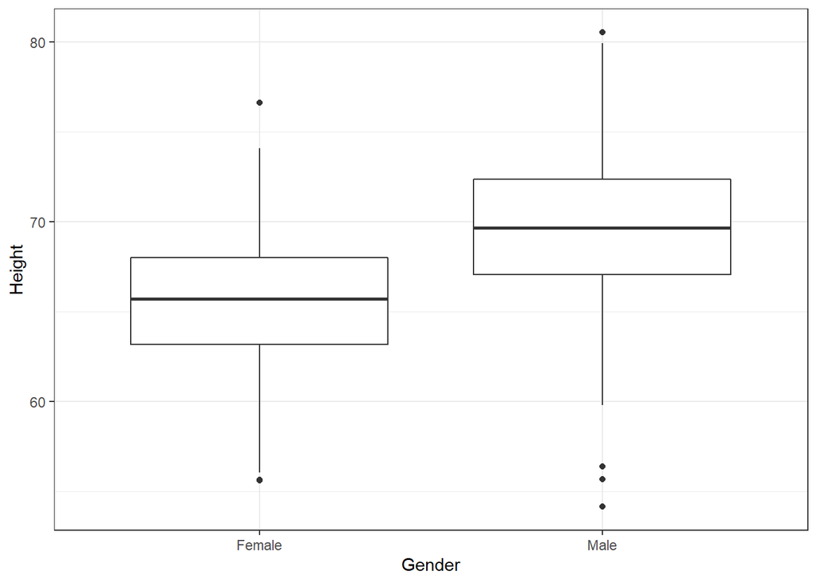

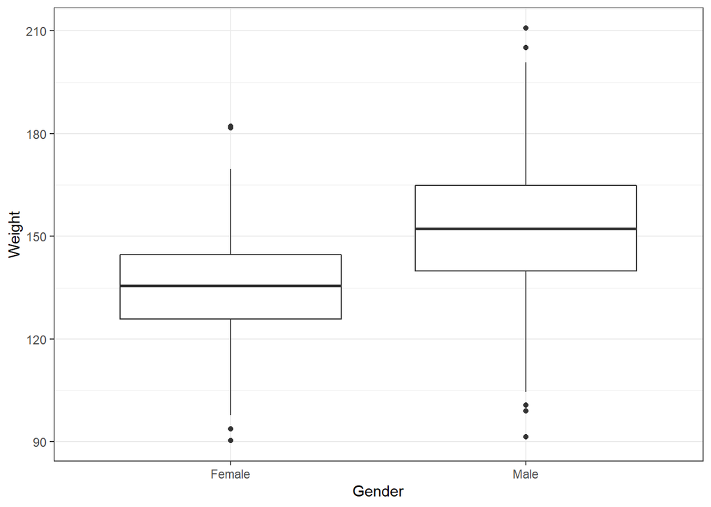

```r
w <- ggplot(data=d, aes(x=d$gender, y=d$weight))
w <- w + geom_boxplot()
w <- w + theme_bw()
w <- w + ylab("Weight")
w <- w + xlab("Gender")
w
```

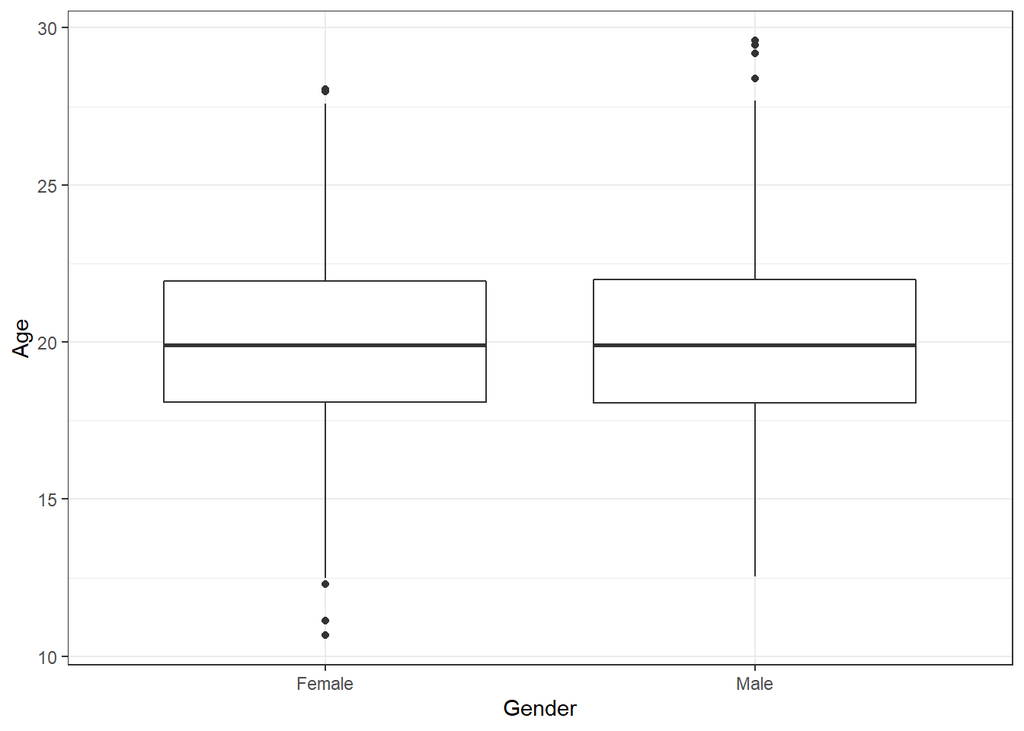

```r
a <- ggplot(data=d, aes(x=d$gender, y=d$age))
a <- a + geom_boxplot()
a <- a + theme_bw()
a <- a + ylab("Age")
a <- a + xlab("Gender")
a
```

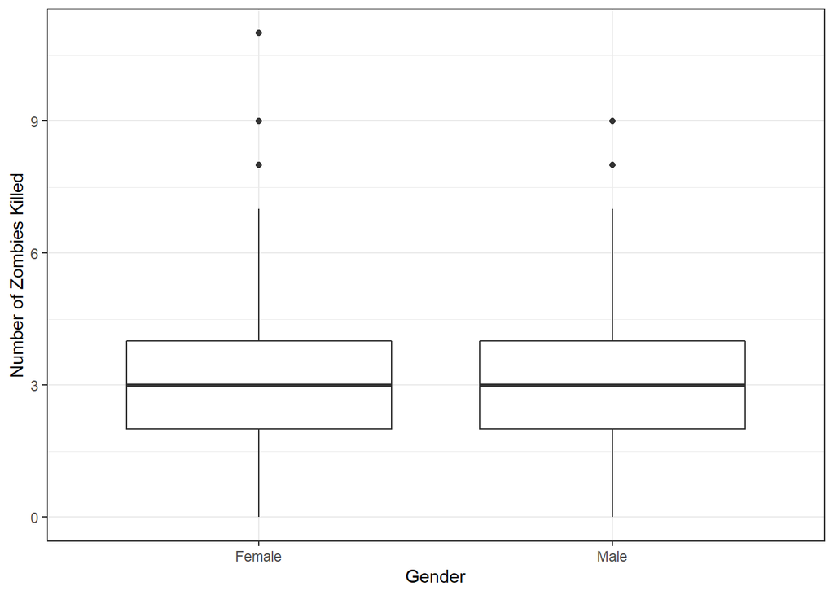

```r
KO <- ggplot(data=d, aes(x=d$gender, y=d$zombies_killed))
KO <- KO + geom_boxplot()
KO <- KO + theme_bw()
KO <- KO + ylab("Number of Zombies Killed")
KO <- KO + xlab("Gender")
KO
```

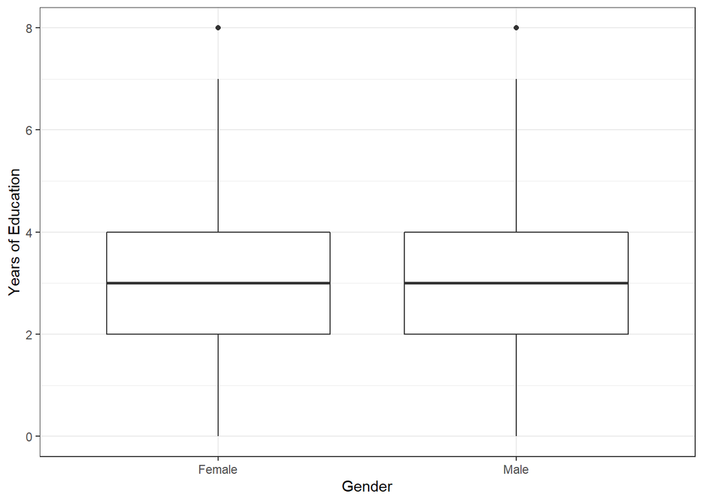

```r
y <- ggplot(data=d, aes(x=d$gender, y=d$years_of_education))
y <- y + geom_boxplot()
y <- y + theme_bw()
y <- y + ylab("Years of Education")
y <- y + xlab("Gender")
y
```

> Use {ggplot} to make scatterplots of height and weight in relation to age. Do these variables seem to be related? In what way?

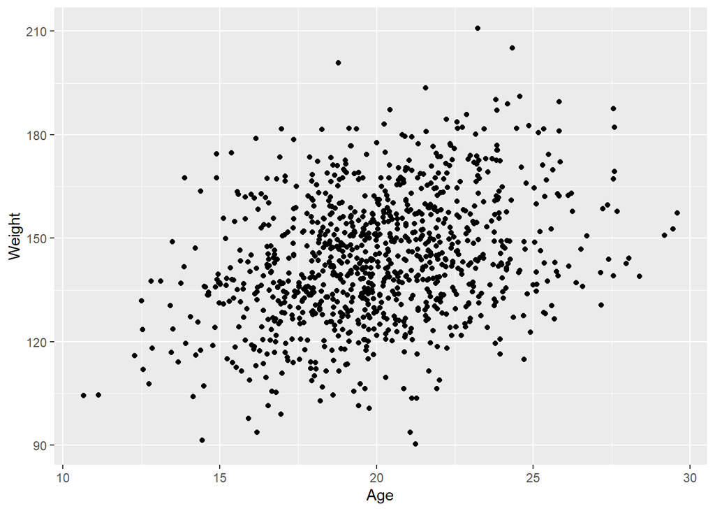

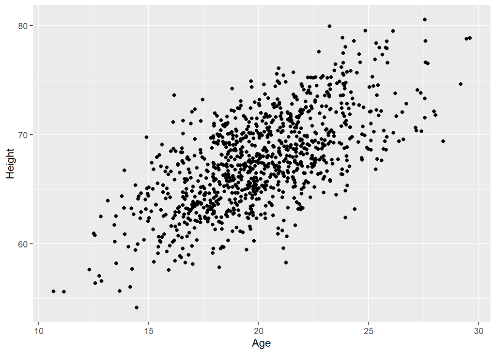

Both height and weight seem to be related to age. As age increases, both other variables tend to increase as well.

> Using histograms and Q-Q plots, check whether the quantitative variables seem to be drawn from a normal distribution. Which seem to be and which do not (hint: not all are drawn from the normal distribution)? For those that are not normal, can you determine from which common distribution they are drawn?

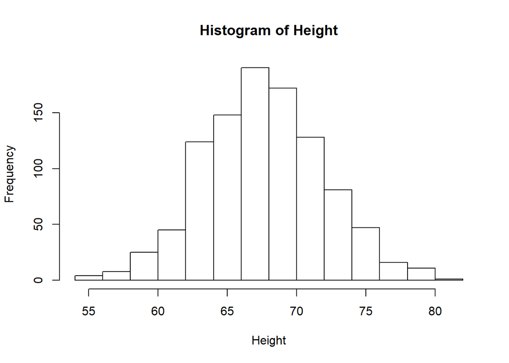

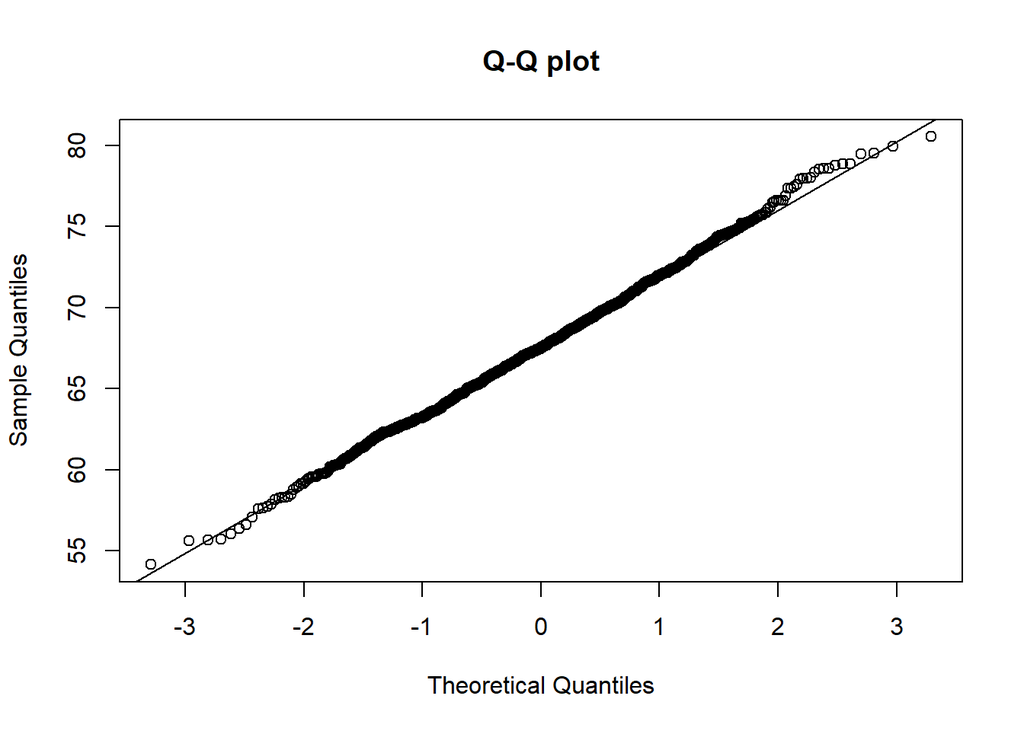

Looks like it fits the line well in the QQ plot and the histogram looks pretty normal

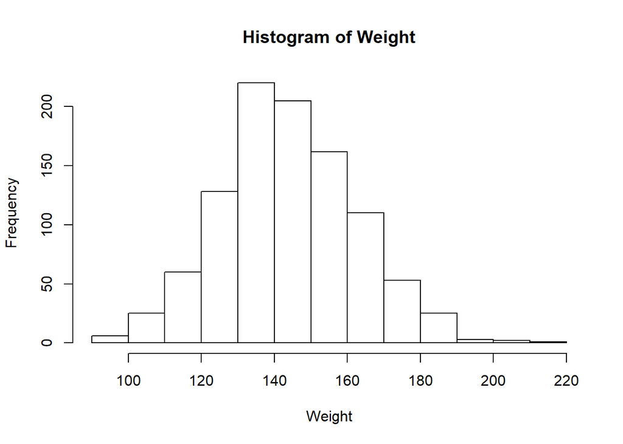

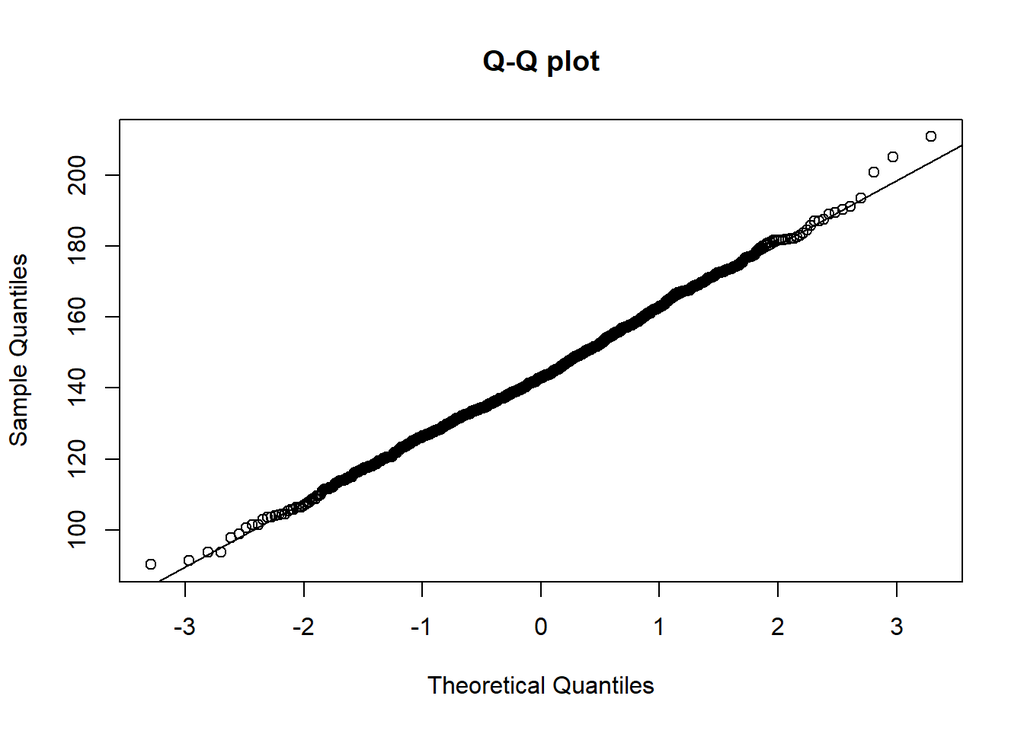

Looks like it fits the line well in the QQ plot and the histogram looks pretty normal

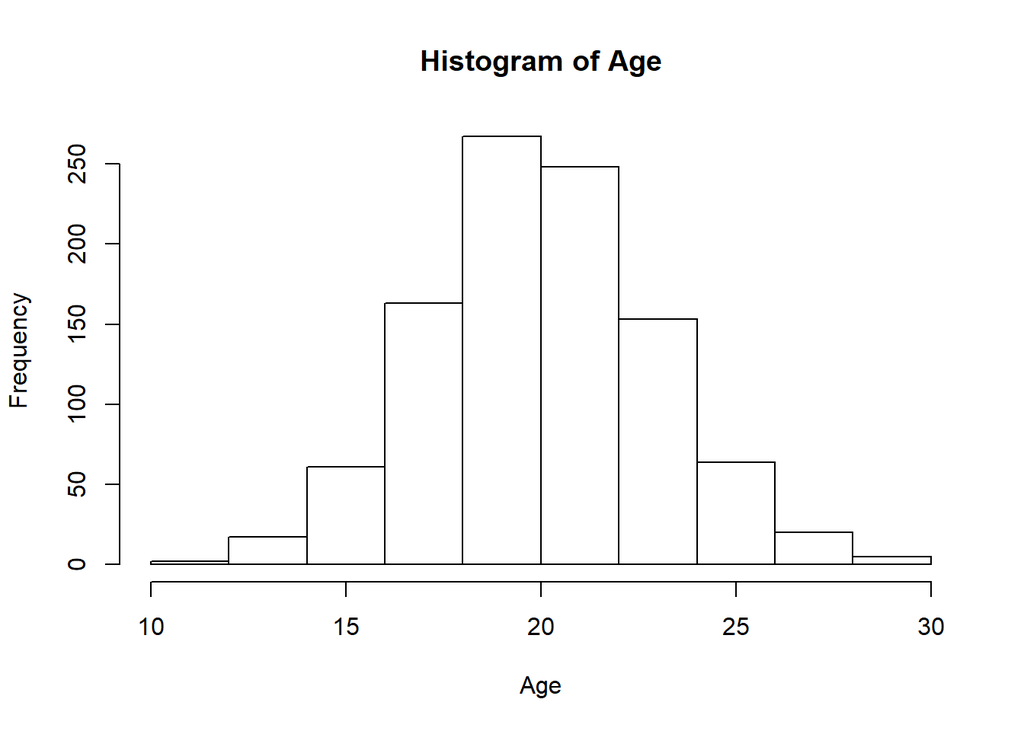

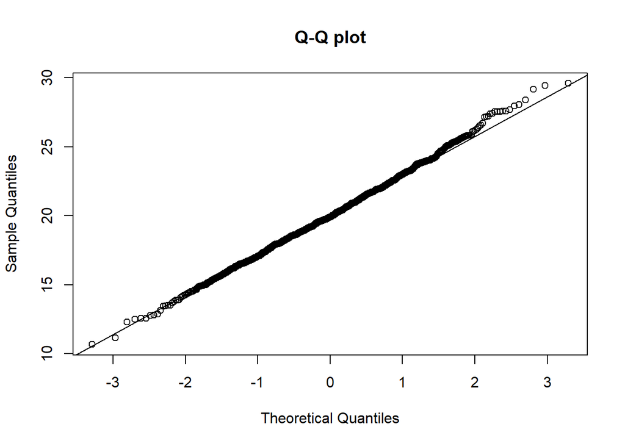

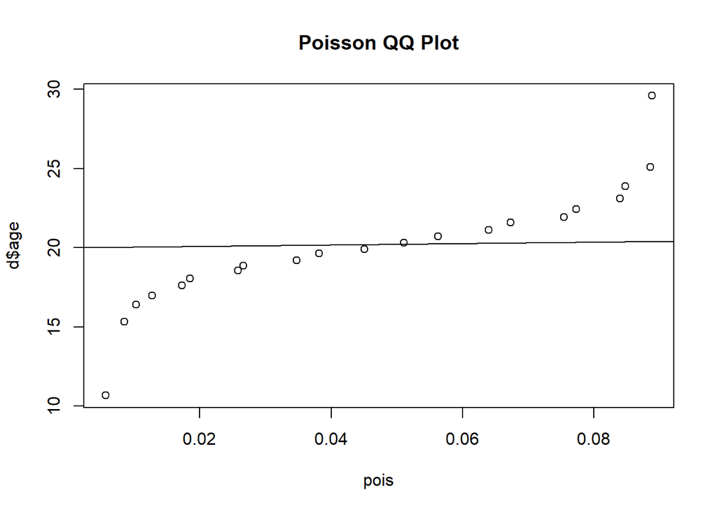

Normal looks much better than the poisson

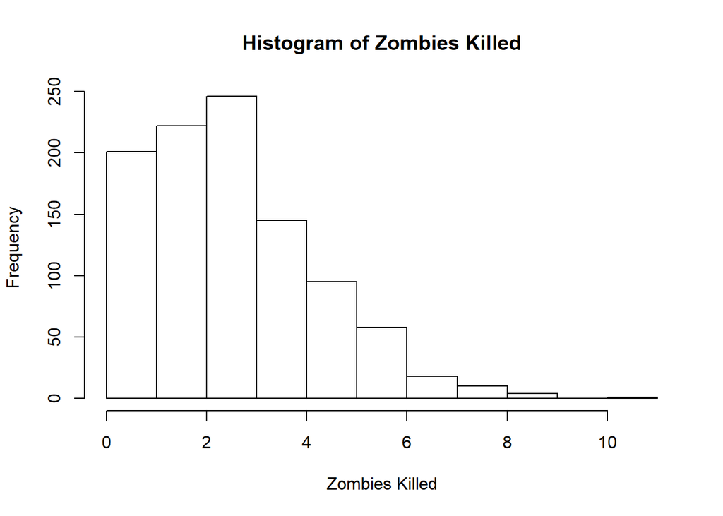

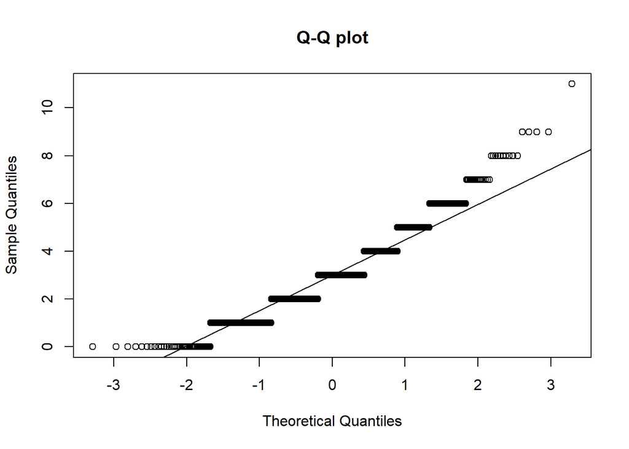

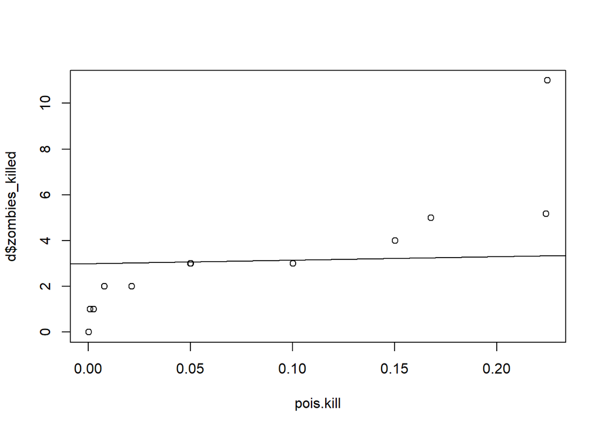

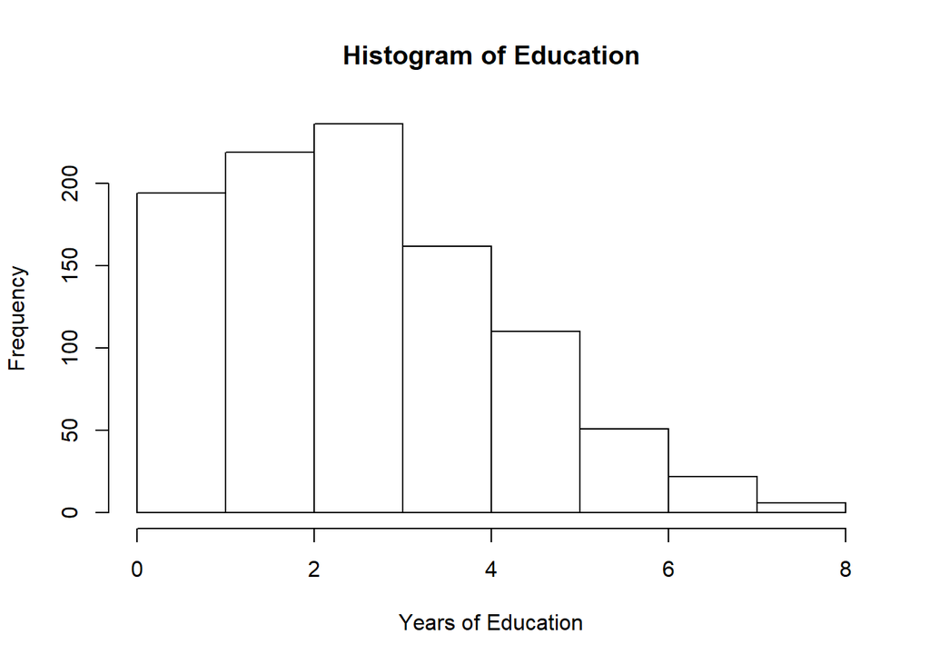

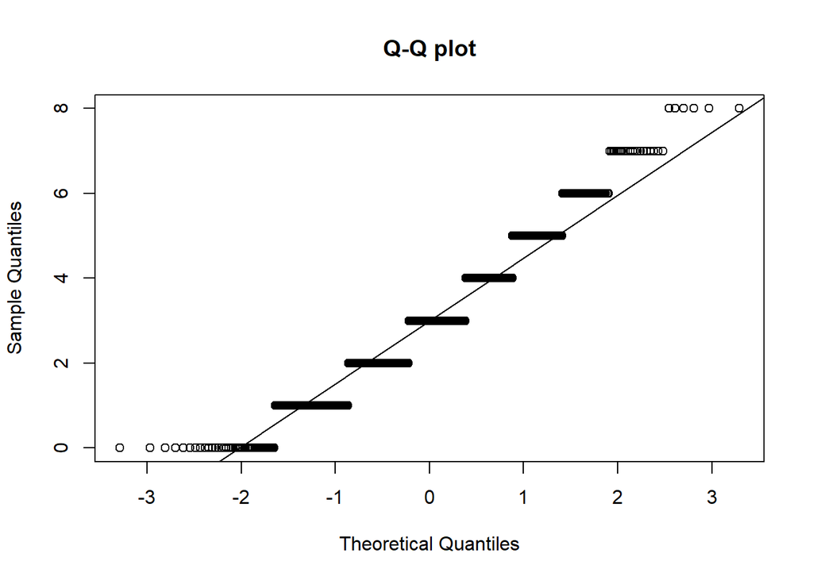

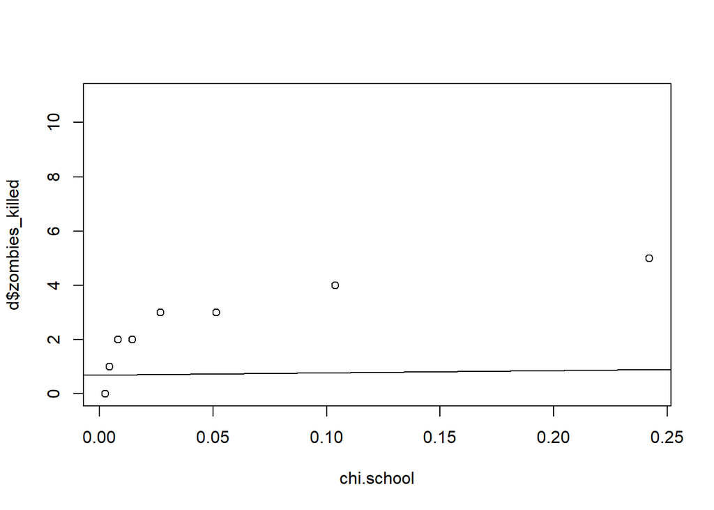

Not a normal distribution, it is very stepwise and needs something that workd with integers, cannot be a negative

For now, I am assuming height, weight, and age are normal and number of zombies killed and years of education are not

#I cannot figure out the distributions. I am not sure if this is becasue I am creating my new QQ plots incorrectly.

> Now use the sample() function to sample ONE subset of 30 zombie survivors (without replacement) from this population and calculate the mean and sample standard deviation for each variable. Also estimate the standard error for each variable, and construct the 95% confidence interval for each mean. Note that for the variables that are not drawn from the normal distribution, you may need to base your estimate of the CIs on slightly different code than for the normal…

```r
#first take the sample and put in a matrix to store the data
d1<-as.data.frame(d[sample(d$id, size = 30, replace = F),])

#Height
d1.height<- mean(d1$height)
height_sd <- sd(d1$height)
se.height<- sd(d1$height)/sqrt(length(d1$height))
lower.height <- d1.height - qnorm(1 - 0.05/2) * se.height  # (1-alpha)/2 each in the upper and lower tails of the distribution
upper.height <- d1.height + qnorm(1 - 0.05/2) * se.height  # (1-alpha)/2 each in the upper and lower tails of the distribution
ci.height <- c(lower.height, upper.height)
ci.height
```

```
## [1] 65.51175 68.53262
```

```r
#Weight
d1.weight<-mean(d1$weight)
weight_sd <- sd(d1$weight)
se.weight<- sd(d1$weight)/sqrt(length(d1$weight))
lower.weight <- d1.weight - qnorm(1 - 0.05/2) * se.weight
upper.weight <- d1.weight + qnorm(1 - 0.05/2) * se.weight
ci.weight <- c(lower.weight, upper.weight)
ci.weight
```

```
## [1] 132.8003 145.6104
```

```r
#Age
d1.age<- mean(d1$age)
age_sd <- sd(d1$age)
se.age<- sd(d1$age)/sqrt(length(d1$age))
lower.age <- d1.age - qnorm(1 - 0.05/2) * se.age
upper.age <- d1.age + qnorm(1 - 0.05/2) * se.age
ci.age <- c(lower.age, upper.age)
ci.age
```

```
## [1] 18.87491 21.55690
```

```r
#thats the normal distributions done

#For these 2 samples we need to use the T-test method...I think

#Number of Zombies Killed
d1.killed<- mean(d1$zombies_killed)
killed_sd <- sd(d1$zombies_killed)
se.kill<- sd(d1$zombies_killed)/sqrt(length(d1$zombies_killed))
lower.kill <- d1.killed - qt(1 - 0.05/2, df = 30 - 1) * se.kill
#df=30-1 because there are 30 individuals in the sample
upper.kill <- d1.killed + qt(1 - 0.05/2, df = 30 - 1) * se.kill
ci.kill <- c(lower.kill, upper.kill)
ci.kill
```

```
## [1] 2.501694 3.431640
```

```r
#Years of Education
d1.school<-mean(d1$years_of_education)
school_sd <- sd(d1$years_of_education)
se.school<- sd(d1$years_of_education)/sqrt(length(d1$years_of_education))
lower.school <- d1.school - qt(1 - 0.05/2, df = 30 - 1) * se.school
upper.school <- d1.school + qt(1 - 0.05/2, df = 30 - 1) * se.school
ci.school <- c(lower.school, upper.school)
ci.school
```

```
## [1] 2.397304 3.802696
```

> Now draw 99 more random samples of 30 zombie apocalypse survivors, and calculate the mean for each variable for each of these samples. Together with the first sample you drew, you now have a set of 100 means for each variable (each based on 30 observations), which constitutes a sampling distribution for each variable.

```r
d.height= NULL
d.weight= NULL
d.age= NULL
d.kill= NULL
d.school= NULL
for(i in 1:100) {
  d.height[i] <-mean(sample(d$height, size = 30, replace = F))
  d.weight[i]<-mean(sample(d$weight, size = 30, replace = F))
   d.age[i]<-mean(sample(d$age, size = 30, replace = F))
  d.kill[i]<-mean(sample(d$zombies_killed, size = 30, replace = F))
  d.school[i]<-mean(sample(d$years_of_education, size = 30, replace = F))
    }
```

> What are the means and standard deviations of this distribution of means for each variable?

```r
mean.height2 <-mean(d.height)
sd.height <- sd(d.height)
mean.height2
```

```
## [1] 67.6788
```

```r
sd.height
```

```
## [1] 0.8680704
```

```r
mean.weight2 <-mean(d.weight)
sd.weight <- sd(d.weight)
mean.weight2
```

```
## [1] 143.8258
```

```r
sd.weight
```

```
## [1] 3.102538
```

```r
mean.age2 <-mean(d.age)
sd.age <- sd(d.age)
mean.age2
```

```
## [1] 20.12105
```

```r
sd.age
```

```
## [1] 0.5089529
```

```r
mean.kill2 <-mean(d.kill)
sd.kill <- sd(d.kill)
mean.kill2
```

```
## [1] 3.002333
```

```r
sd.kill
```

```
## [1] 0.3169458
```

```r
mean.school2 <-mean(d.school)
sd.school <- sd(d.school)
mean.school2
```

```
## [1] 3.007667
```

```r
sd.school
```

```
## [1] 0.2783572
```

> How do the standard deviations of means compare to the standard errors estimated in [5]?

```r
labels <- c("Measurement", "SD of Means", "Estimated SE")
height <- c("height", sd.height, se.height)

weight <- c("weight", sd.weight,
se.weight)

age <- c("Age", sd.age, se.age)
kill <- c("Zombies Killed", sd.kill, se.kill)

school <- c("school", sd.school,
se.school)

rbind( labels, height, weight, age, kill, school)
```

```
##        [,1]             [,2]                [,3]
## labels "Measurement"    "SD of Means"       "Estimated SE"
## height "height"         "0.868070353768684" "0.770643454406823"
## weight "weight"         "3.10253758193837"  "3.26793699395238"
## age    "Age"            "0.508952897346927" "0.684192313268791"
## kill   "Zombies Killed" "0.316945827686674" "0.227345164353213"
## school "school"         "0.278357173518813" "0.343578196356367"
```

> What do these sampling distributions look like (a graph might help here)? Are they normally distributed? What about for those variables that you concluded were not originally drawn from a normal distribution?

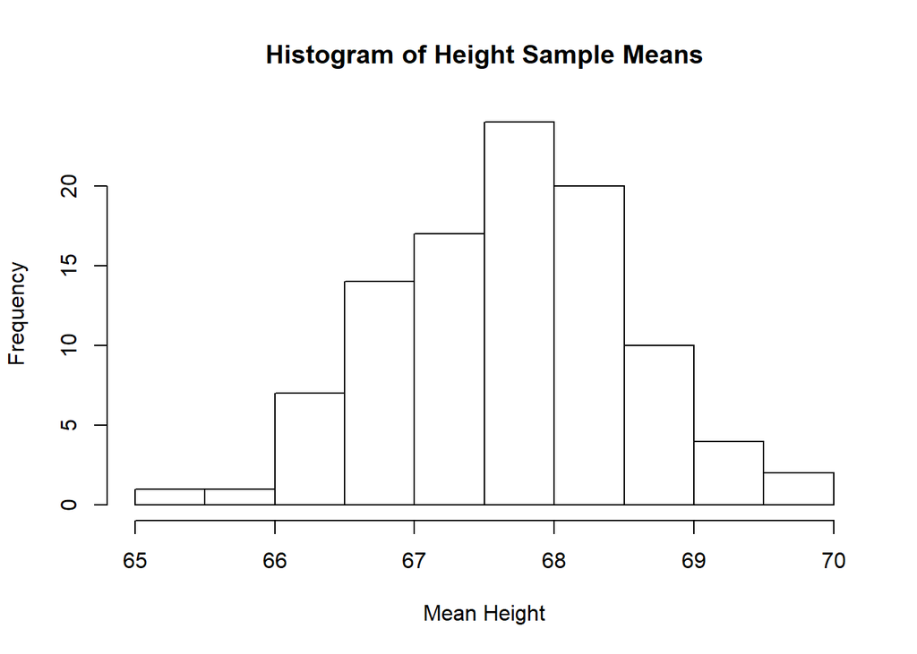

```r
hist(d.height, main=("Histogram of Height Sample Means"), xlab="Mean Height")
```

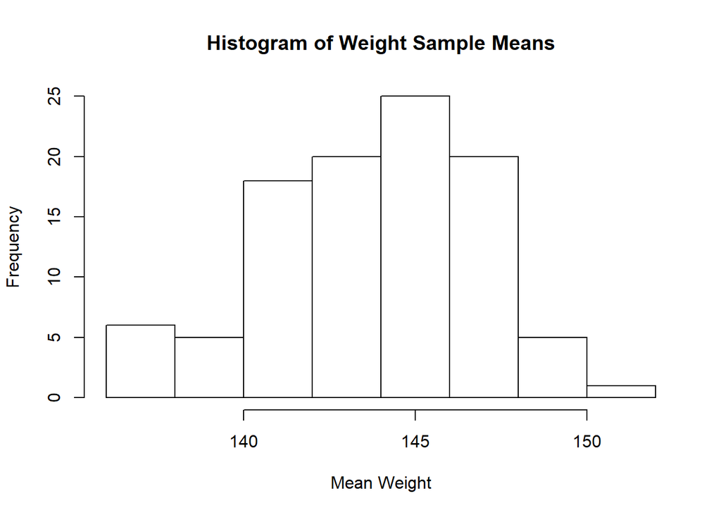

```r
hist(d.weight, main=("Histogram of Weight Sample Means"), xlab="Mean Weight")
```

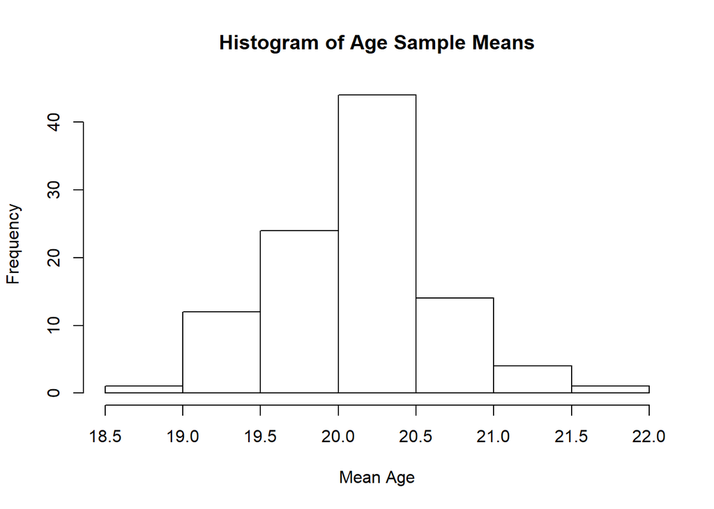

```r
hist(d.age, main=("Histogram of Age Sample Means"), xlab="Mean Age")
```

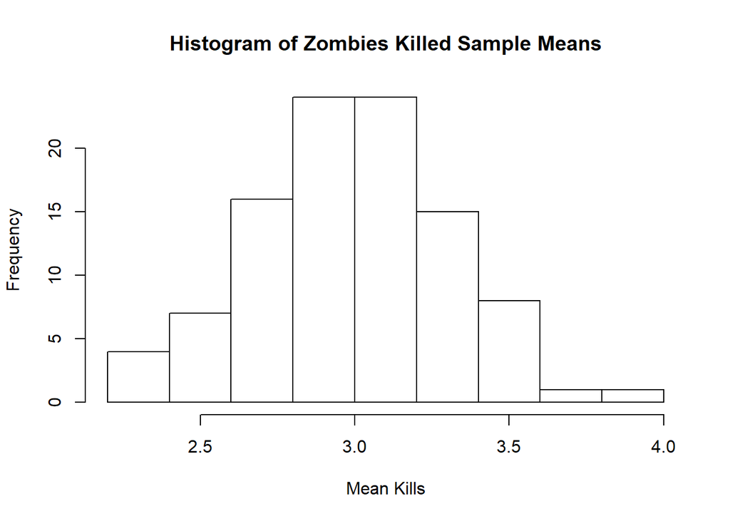

```r
hist(d.kill, main=("Histogram of Zombies Killed Sample Means"), xlab="Mean Kills")
```

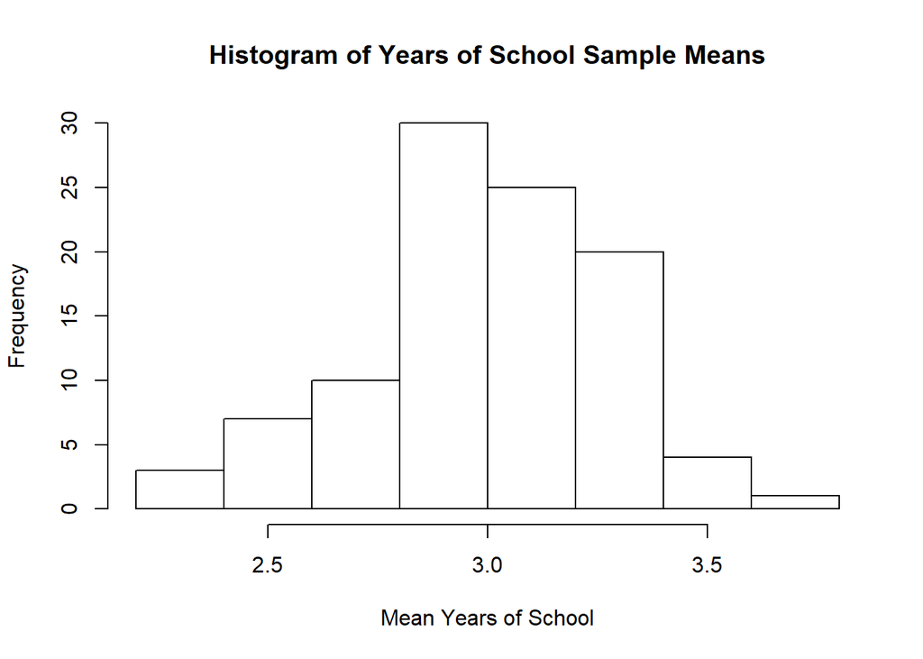

```r
hist(d.school, main=("Histogram of Years of School Sample Means"), xlab="Mean Years of School")
```

Some of the histograms look normal, though some are skewed. It doesnt necessarily correlate with if they originally seemed normal

> 5 Challenges

I keep getting errors when I load the libraries at the beginning of the document. I googled it and found that updating the packages would help. It did not.

I cannot figure out the distributions for the variables. I am not sure if this is becasue I am creating my new QQ plots incorrectly.

I dont know how well the ends of QQ plots should fit the line to count as probably a normal distribution.

I had to find a better way to show the difference between the standard deviations of means compared to the standard errors

I tried to add a theme but I cannot get it to work. It should have a banner at the top of the knitted document.